# Comcast Telecom Consumer Complaints

**Objective :** Detailed level analysis of customer complaints filed against Comcast's customer service to improve on the service in the Telecom sector.

## Analysis Tasks

### Declare all necessary Libraries

```python
import pandas as pd
import numpy as np

import matplotlib.pyplot as plt
import seaborn as sns
%matplotlib inline
```

### Reading a file

The file contains the column Date with the value Date type, to load it as a date data type and to recognize the month correctly use the parse_dates and dayfirst parameters while reading the file.

```python
# Reading csv data file with date formats
df = pd.read_csv('Comcast_telecom_complaints_data.csv', parse_dates=["Date"], dayfirst=True)
```

```python
df.info()
```

```
<class 'pandas.core.frame.DataFrame'>
RangeIndex: 2224 entries, 0 to 2223
Data columns (total 11 columns):
 #   Column                       Non-Null Count  Dtype
---  ------                       --------------  -----
 0   Ticket #                     2224 non-null   object
 1   Customer Complaint           2224 non-null   object
 2   Date                         2224 non-null   datetime64[ns]
 3   Date_month_year              2224 non-null   object
 4   Time                         2224 non-null   object
 5   Received Via                 2224 non-null   object
 6   City                         2224 non-null   object
 7   State                        2224 non-null   object
 8   Zip code                     2224 non-null   int64
 9   Status                       2224 non-null   object
 10  Filing on Behalf of Someone  2224 non-null   object
dtypes: datetime64[ns](1), int64(1), object(9)
memory usage: 191.2+ KB
```

```python
#check for null values if any
df.isnull().sum()
```

```
Ticket #                       0
Customer Complaint             0
Date                           0
Date_month_year                0
Time                           0
Received Via                   0
City                           0
State                          0
Zip code                       0
Status                         0
Filing on Behalf of Someone    0
dtype: int64
```

```python
df.shape
```

```
(2224, 11)
```

```python
df.head(2)
```

|  | Ticket # | Customer Complaint | Date | Date_month_year | Time | Received Via | City | State | Zip code | Status | Filing on Behalf of Someone |
| --- | --- | --- | --- | --- | --- | --- | --- | --- | --- | --- | --- |
| 0 | 250635 | Comcast Cable Internet Speeds | 2015-04-22 | 22-Apr-15 | 3:53:50 PM | Customer Care Call | Abingdon | Maryland | 21009 | Closed | No |
| 1 | 223441 | Payment disappear - service got disconnected | 2015-08-04 | 04-Aug-15 | 10:22:56 AM | Internet | Acworth | Georgia | 30102 | Closed | No |

**Task#1 :** Provide the trend chart for the number of complaints at monthly and daily granularity levels.

```python
#Create the features for Day and Month
df["Month_name"]= pd.DatetimeIndex(df["Date"]).month_name()
df["Day"]= pd.DatetimeIndex(df["Date"]).day
```

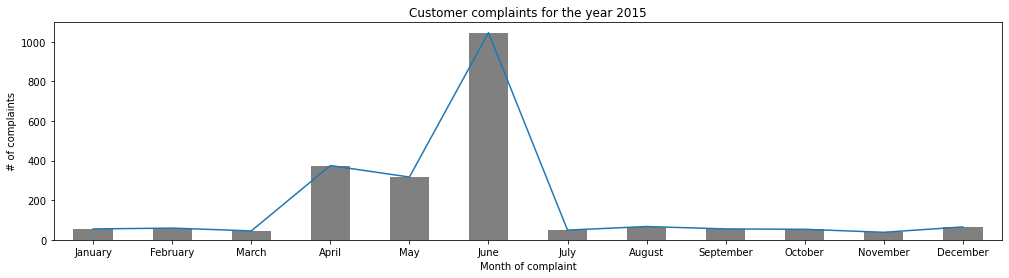

```python
plt.figure(figsize=(17,4))
ax = df.groupby('Month_name').count().sort_index(key=lambda x: pd.to_datetime(x, format="%B"))["Ticket #"].plot(kind='bar', color='grey')
ax = df.groupby('Month_name').count().sort_index(key=lambda x: pd.to_datetime(x, format="%B"))["Ticket #"].plot(kind='line')
plt.title("Customer complaints for the year 2015")
plt.xlabel("Month of complaint")
plt.ylabel("# of complaints")
plt.xticks(rotation=0)
plt.show()
```

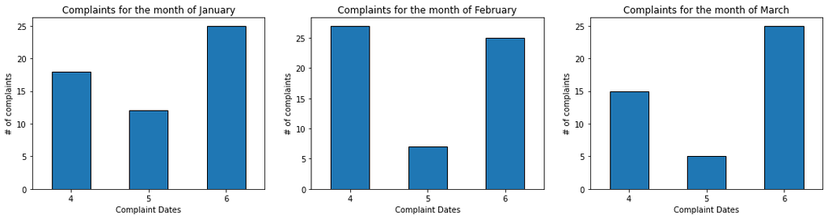

```python
Month_list = ['January', 'February', 'March']
plt.figure(figsize=(18,4))
for index, val in enumerate(Month_list):
    ax = plt.subplot(1, 3, index+1)
    df[df.Month_name == val].groupby("Day")["Ticket #"].count().plot(kind='bar', edgecolor='black')
    plt.title('Complaints for the month of {}'.format(val))
    plt.xticks(rotation=0)
    plt.xlabel('Complaint Dates')
    plt.ylabel('# of complaints')
plt.show()
```

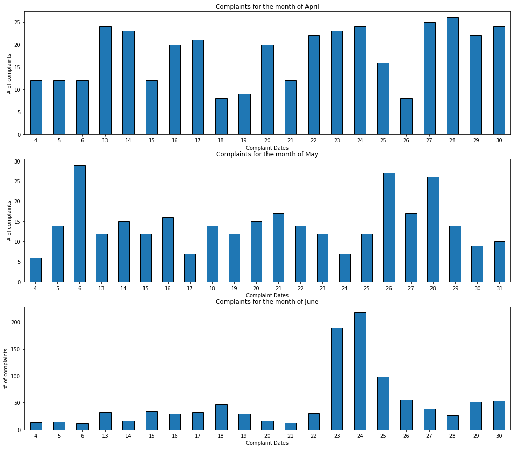

```python
Month_list = ['April', 'May', 'June']
plt.figure(figsize=(17,15))
for index, val in enumerate(Month_list):
    ax = plt.subplot(len(Month_list), 1, index+1)
    df[df.Month_name == val].groupby("Day")["Ticket #"].count().plot(kind='bar', edgecolor='black')
    plt.title('Complaints for the month of {}'.format(val))
    plt.xticks(rotation=0)
    plt.xlabel('Complaint Dates')
    plt.ylabel('# of complaints')
plt.show()
```

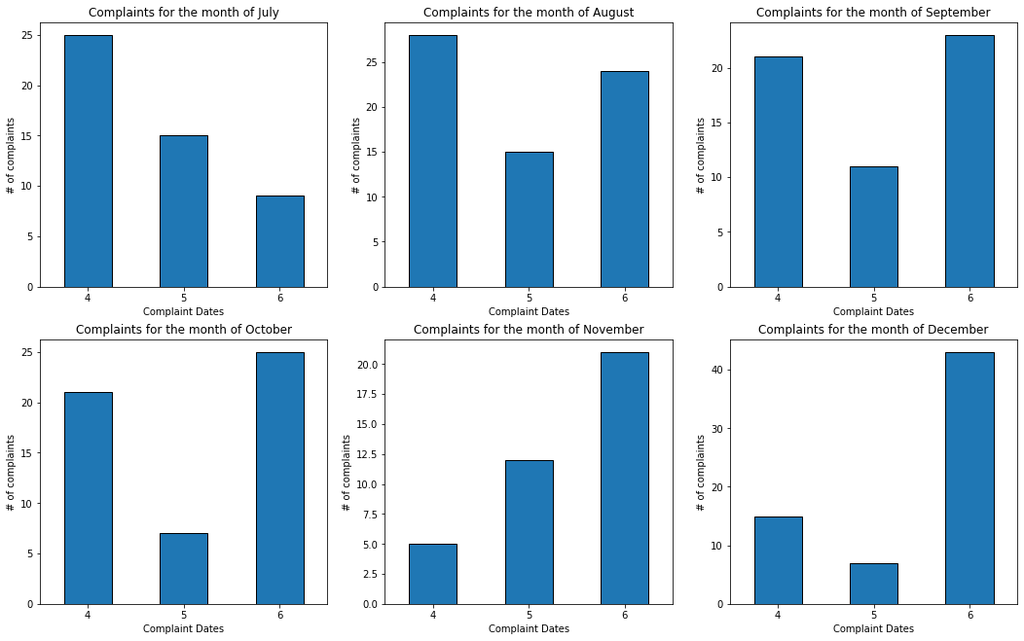

```python
Month_list = ['July', 'August', 'September', 'October', 'November', 'December']
plt.figure(figsize=(18,11))
for index, val in enumerate(Month_list):
    ax = plt.subplot(2, 3, index+1)
    df[df.Month_name == val].groupby("Day")["Ticket #"].count().plot(kind='bar', edgecolor='black')
    plt.title('Complaints for the month of {}'.format(val))
    plt.xticks(rotation=0)
    plt.xlabel('Complaint Dates')
    plt.ylabel('# of complaints')
plt.show()
```

**Conclusion :**

- June month has highest number of complaints accounting to 47%
- 78% of the complaints are logged in the month of April, May and June
- For rest of the months, complaints are logged only on 4th, 5th and 6th day of the month.

**Task#2 :** Provide a table with the frequency of complaint types

Some of the complaint types which can be categorised are internet issues

```python
#Create a new feature for the complain type and categorise the complaints based on the text provided in the complaints
df['Complaint_type'] = ""
df.loc[df["Customer Complaint"].str.contains("account", case=False), ['Complaint_type']] = "Account related issues"
df.loc[((df["Customer Complaint"].str.contains("cable|connect", case=False)) & (df["Complaint_type"] == "")), ['Complaint_type']] = "Comcast cable/connection issues"
df.loc[((df["Customer Complaint"].str.contains("Pay|charg|bill|fee|pmts|credit", case=False)) & (df["Complaint_type"] == "")), ['Complaint_type']] = "Billing issues"
df.loc[((df["Customer Complaint"].str.contains("pric|rate", case=False)) & (df["Complaint_type"] == "")), ['Complaint_type']] = "Pricing issues"
df.loc[((df["Customer Complaint"].str.contains("refund", case=False)) & (df["Complaint_type"] == "")), ['Complaint_type']] = "Refund issues"
df.loc[((df["Customer Complaint"].str.contains("speed|slow|bandwidth|throttling", case=False)) & (df["Complaint_type"] == "")), ['Complaint_type']] = "Speed issues"
df.loc[((df["Customer Complaint"].str.contains("cap|data", case=False)) & (df["Complaint_type"] == "")), ['Complaint_type']] = "Data issues"
df.loc[((df["Customer Complaint"].str.contains("internet", case=False)) & (df["Complaint_type"] == "")), ['Complaint_type']] = "Internet issues"
df.loc[((df["Customer Complaint"].str.contains("Xfinity|hbo", case=False)) & (df["Complaint_type"] == "")), ['Complaint_type']] = "Comcast Xfinity/HBO service issues"
df.loc[df["Complaint_type"] == "", ['Complaint_type']] = "Comcast service related issues"
```

```python
df.groupby('Complaint_type').size().sort_values(ascending=False)
```

```
Complaint_type
Comcast service related issues        654
Billing issues                        585
Internet issues                       239
Speed issues                          209
Data issues                           205
Comcast cable/connection issues       121
Pricing issues                        100
Comcast Xfinity/HBO service issues     79
Account related issues                 26
Refund issues                           6
dtype: int64
```

**Task#3 :** Create a new categorical variable with value as Open and Closed. Open & Pending is to be categorized as Open and Closed & Solved is to be categorized as Closed.

```python
df.Status.value_counts()
```

```
Solved     973
Closed     734
Open       363
Pending    154
Name: Status, dtype: int64
```

```python
df["Current_status"] = ""
df.loc[(df["Status"].str.contains("Open|Pending")), ["Current_status"]] = "Open"
df.loc[(df["Status"].str.contains("Closed|Solved")), ["Current_status"]] = "Closed"
```

```python
df.Current_status.value_counts()
```

```
Closed    1707
Open       517
Name: Current_status, dtype: int64
```

**Task#4 :** Provide state wise status of complaints in a stacked bar chart. Use the categorized variable from Q3. Provide insights on:

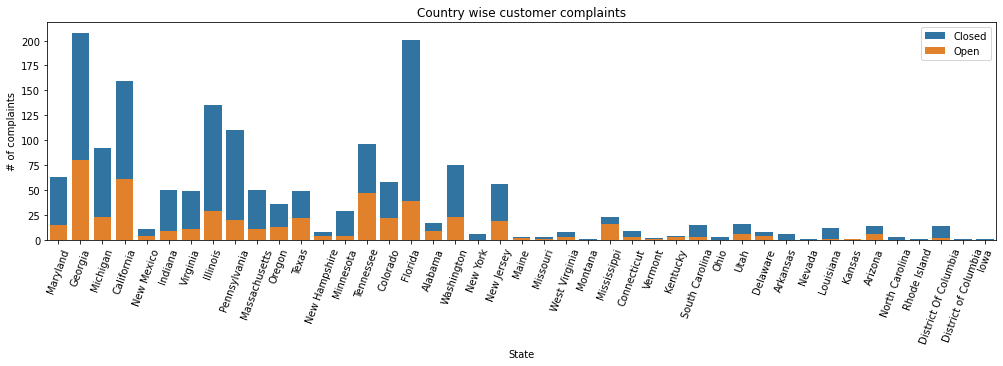

```python
plt.figure(figsize=(17,4))
ax = sns.countplot(x="State", data=df, hue="Current_status", dodge=False)
plt.title("Country wise customer complaints")
plt.ylabel("# of complaints")
plt.legend(loc='upper right')
plt.xticks(rotation=70)
plt.show()
```

```python
#State wise complaints sorted by highest complaints
df.groupby("State").size().sort_values(ascending=False).head()
```

```
State
Georgia       288
Florida       240
California    220
Illinois      164
Tennessee     143
dtype: int64
```

```python
#State wise complaints sorted by closed complaints
df[df["Current_status"] == "Closed"].groupby("State").size().sort_values(ascending=False).head()
```

```
State
Georgia         208
Florida         201
California      159
Illinois        135
Pennsylvania    110
dtype: int64
```

```python
#State wise complaints sorted by open complaints
df[df["Current_status"] == "Open"].groupby("State").size().sort_values(ascending=False).head()
```

```
State
Georgia       80
California    61
Tennessee     47
Florida       39
Illinois      29
dtype: int64
```

**Task#5 :** Which state has the maximum complaints.

```python
#State wise complaints sorted by highest complaints
df.groupby("State").size().sort_values(ascending=False).head()
```

```
State
Georgia       288
Florida       240
California    220
Illinois      164
Tennessee     143
dtype: int64
```

State **Georgia** has the maximum complaints of 288 and 80 are still in open state.

**Task#6 :** Which state has the highest percentage of unresolved complaints

```python
df_total_tickets = df.groupby('State')[["Ticket #"]].count()
df_unresolved_tickets = df[df.Current_status == "Open"].groupby('State')[["Current_status"]].count()
df_complaints = pd.merge(df_total_tickets, df_unresolved_tickets, on="State", how='left')
df_complaints.rename(columns={"Ticket #": "Logged", "Current_status": "Unresolved"}, inplace=True)
df_complaints.fillna(0, inplace=True)
df_complaints["Pct_Unresolved"] = np.round(df_complaints.Unresolved/df_complaints.Logged * 100, 2)
df_complaints.sort_values(by="Pct_Unresolved", ascending=False).head()
```

| State | Logged | Unresolved | Pct_Unresolved |
| --- | --- | --- | --- |
| Kansas | 2 | 1.0 | 50.00 |
| Kentucky | 7 | 3.0 | 42.86 |
| Mississippi | 39 | 16.0 | 41.03 |
| Maine | 5 | 2.0 | 40.00 |
| Alabama | 26 | 9.0 | 34.62 |

**Kansas** state has highest % of unresolved complaints

**Task#7 :** Provide the percentage of complaints resolved till date, which were received through the Internet and customer care calls.

```python
df_total_tickets = df.groupby('Received Via')[["Ticket #"]].count()
df_resolved_tickets = df[df.Current_status == "Closed"].groupby('Received Via')[["Current_status"]].count()
df_complaints = pd.merge(df_total_tickets, df_resolved_tickets, on="Received Via")
df_complaints.rename(columns={"Ticket #": "Logged", "Current_status": "Resolved"}, inplace=True)
df_complaints["Pct_resolved"] = np.round(df_complaints.Resolved/df_complaints.Logged * 100, 2)
df_complaints
```

| Received Via | Logged | Resolved | Pct_resolved |
| --- | --- | --- | --- |
| Customer Care Call | 1119 | 864 | 77.21 |
| Internet | 1105 | 843 | 76.29 |

**Conclusion :**  
**77.21%** of the complaints logged through Customer Care Call has been resolved till date.  
**76.29%** of the complaints logged through Internet has been resolved till date.